## HW 4

Nicole Black

```python
import numpy as np
import matplotlib.pyplot as plt
```

1. The Malthusian growth equation can be written as: $\frac{dN}{dt} = \alpha N$, where N is the number of people and $\alpha$ is a constant parameter.

a. Solve this equation to find N(t), the population size as a function of time. Initially, at t=0, the population size is 10.

$\frac{dN}{dt} = \alpha N$ // separate variables N and $\alpha$

$\frac{1}{N} \times \frac{dN}{dt} = \alpha$ // integrate with respect to time, t

$\int \frac{1}{N} \times dN = \int \alpha \times dt$ // solve

$ln |N| = \alpha t + C$ // solve for C using N(0) = 10

$ln |10| = \alpha * 0 + C$

$C = ln |10|$ // plug back in

The equation N(t) is: $N(t) = e^{\alpha t} * 10$

b. If $\alpha = 1$, sketch the first three time points (t=0,1,2) for N(t). You can approximate e as 2.7.

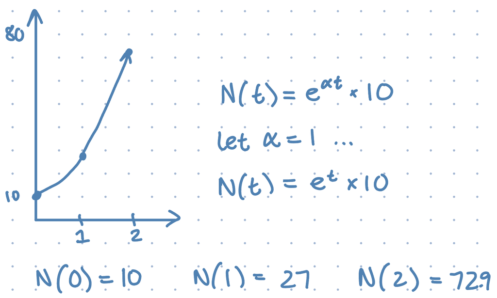

c. If food becomes limited for this population, write down a new differential equation for the rate of change of the population. Describe its terms.

To limit the population, we can introduce K, or carrying capacity, which represents the max population that can be supported given the constrainst of the environment. K is integrated into the Malthusian equation with the equation $\frac{dN}{dt} = \alpha N(1 - \frac{N}{K})$.

Here, $\frac{dN}{dt}$ represents the change in population over time, $\alpha N$ represents the growth rate given infinite resources, and $1- \frac{N}{K}$ represents positive or negative difference bewteen the current population and the max population supported, K. When N >> K, this term is a large negative, and so the change in population will decrease quickly. When K >> N, this term is positive and very close to one, so the growth will be modeled by $\alpha N$. If K and N are approximately equal, the term will be near 0, so growth/decay will be small or nonexistant.

1. General knowledge of ODE modeling.

a. In words: define what is a steady state.

A steady state is a solution for the system (x/y, infected/healthy, lynx/hare) where the system is not changing. For example, if there are 0 infected people and 100 healthy people, this system would be at an equilibrium where no people are leaving/joining either population group.

b. Mathematically: define what is a steady state.

Mathematically, a steady state is defined where the derivatives with respect to each dependent variable are 0. In the example above, the dependent variables are population sick (s) and population healthy (h). The derivatives at steady state are $\frac{ds}{dt} = 0$ and $\frac{dh}{dt} = 0$.

c. In words: define what it means if a steady state is stable.

A stable steady state is one that can survive relatively small perterbtions before returning back to that steady state.

d. Mathematically: define the conditions under which a steady state is stable.

Mathematically, a steady state, $(x*, y*)$, is stable if every solution (x,y) near $(x*, y*)$ converges to $(x*, y*)$ as time t approaches $\infty$.

1. For the following system of ODEs: $$x' = x - ay$$ $$y' = 4x - y - 2$$

a. Solve to find the steady states (fixed points) in terms of the parameter $a$.

// set the derivates $x'$ and $y'$ equal to 0

$x' = 0 = x - ay$

$y' = 0 = 4x - y - 2$

// rearrange

$x = ay = -\frac{25a}{1-4a}$

$y = -\frac{25}{1-4a}$

where $a\neq \frac{1}{4}$

b. Let $\alpha$ = 5 and use Euler’s method to simulate the model for two time steps with $\Delta t = 0.1$, starting from the point ($x_0$, $y_0$) = (6, 0.1). Sketch the solution on ($x$, $y$) plane.

$x(t+\Delta t) = x(t) + \Delta t \times (x(t) - ay(t))$

$y(t+\Delta t) = y(t) + \Delta t \times (4x(t) - y(t) - 2)$

// let $\alpha = 5$, $\Delta t = 0.1$, and ($x_0$, $y_0$) = (6, 0.1)

// t = 0

($x_0$, $y_0$) = (6, 0.1)

// time step 1 (t = 0.1)

$x(0+0.1) = 6 + 0.1 \times (6 - 5 \times 0.1) = 6.55$

$y(0+0.1) = 0.1 + 0.1 \times (4 \times 6 - 0.1 - 2) = 2.29$

// time step 2 (t = 0.2)

$x(0.1+0.1) = 6.55 + 0.1 \times (6.55 - 5 \times 2.29) = 6.06$

$y(0.1+0.1) = 2.29 + 0.1 \times (4 \times 6.55 - 2.29 - 2) = 4.481$

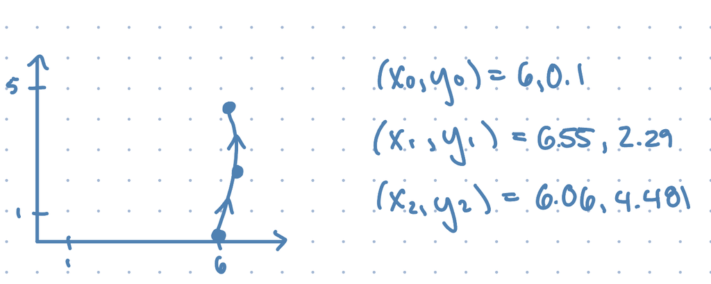

1. Foxes (F) eat rabbits (R) at rate $b$. Assume that the rabbit population can grow with a growth rate of 3, subject to a crowding factor that limits the total population size to 100. Assume that the fox population only grows by eating rabbits, but that foxes die at a rate of 10.

a. Write down the differential equation model for the rates of change of rabbits (dR/dt) and foxes (dF/dt).

$\frac{dR}{dt} = 3R(1-\frac{R}{100}) - bRF$

$\frac{dF}{dt} = bRF - 10F$

b. Let $b = 2$ and let the initial populations sizes of rabbits and foxes be given by $(R(t_0), F(t_0)) = 10,2)$. Find the rate of change of the two populations at $t_0$, and describe in words what is happening to each population (growing or shrinking?).

// substitute $b=2$, $R(0) = 10$ and $F(0) = 2$

$\frac{dR}{dt} = (3)(10)(1-\frac{10}{100}) - 2(10)(2)$

$\frac{dF}{dt} = (2)(10)(2) - 10(2)$

// solve

$\frac{dR}{dt} = -13$

$\frac{dF}{dt} = 20$

Given $b=2$ and the starting solution $(R(t_0), F(t_0)) = 10,2)$, the rabbit derivate $\frac{dR}{dt}$ is negative and the fox derivating $\frac{dF}{dt}$ is positive, hence the rabbit population is decreasing at a rate of -13 rabbits per time step and the fox population is increasing at a rate of 20 foxes per time step.

1. Simply put, Hebb’s rule states that “neurons that fire together, wire together.” More precisely, the synaptic efficacy between sets of neurons increases the more frequently that set of neurons fires simultaneously. Consider a simple example of Hebb’s rule consisting of two neurons firing one postsynaptic neuron:

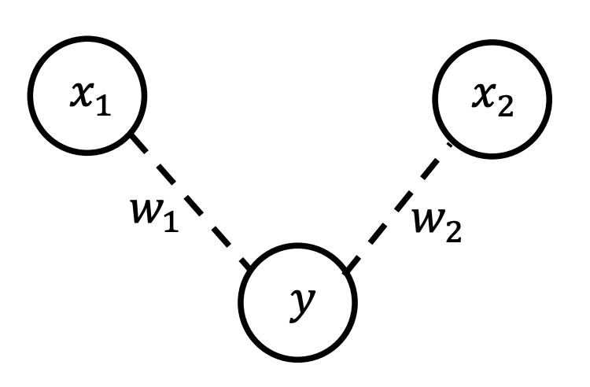

Here, $x_1, x_2$ give the activity/firing levels of the input (presynaptic) neurons, and $y$ gives the activity/firing level of the output (postsynaptic) neuron. $w_1, x_2$ are the efficacies between the pairs of neurons as shown above. We will assume that the values of $x_1, x_2$, are always positive (the neurons $x_1, x_2$ fire) and the values $w_1, w_2$ are always non-negative (meaning $x_1$ and $x_2$ cannot inhibit neuron $y$ from firing). According to Hebb’s rule, the more frequently $x_1$ and $y$ fire together, the larger the value $w_1$ will become, and likewise for $w_2$. We represent this as mathematical model described by the ODEs:

$\frac{dw_i}{dt} = x_iy$ for $i=1,2$ where the firing of neuron y is given by $y = x_1w_1+x_2w_2$.

a. Solve to find the fixed point of this system.

// set the derivatives equal to 0

$\frac{dw_1}{dt} = x_1y = 0$

$\frac{dw_2}{dt} = x_2y = 0$

// solve for y

$\frac{dw_1}{dt} = x_1y = 0$ // divide by $x_1$

$y = \frac{0}{x_1} = 0$

$y = 0$

// plug in

$y = 0 = x_1w_1+x_2w_2$

$x_1w_1 = -x_2w_2$

Given that $x_1$ and $x_2$ must be positive, for $x_1w_1 = -x_2w_2$, $w_1$ and $w_2$ must be 0.

Our fixed point is $(w_1, w_2) = (0,0)$

b. Is the fixed point stable or unstable? Explain your reasoning.

Let $\frac{dw_1}{dt} = 0$, $\frac{dw_2}{dt} = x_1(x_1w_1+x_2w_2)$

Solve $\frac{dw_2}{dt}|_{w_2=0+\alpha}$, where $\alpha$ is a positive pertubation of $w_2$.

$\frac{dw_2}{dt}|_{w_2=0+\alpha} = x_1x_2\alpha$

Since $x_1,x_2,$ and $\alpha$ are always positive, $\frac{dw_2}{dt}|_{w_2=0+\alpha}$ is also positive. Hence, given a pertubation of $w_2$ in the positive direction, the derivative $\frac{dw_2}{dt}$ grows, rather than returning to 0, and the fixed point is unstable.

We do not need to do the above calculations for a pertubation in $w_1$ since the fixed point is already unstable in one direction (but if we did do it, we would find the same thing).

c. Consider a modified model where the value of $w_1$ is bounded by a constant parameter, $\gamma$. The new model is:

$\frac{dw_i}{dt} = x_iy(\gamma-w_i)$, for $i=1,2$

Solve to find the fixed point(s) of this system.

// set the derivatives equal to 0

$\frac{dw_1}{dt} = x_1y(\gamma-w_1) = 0$

$\frac{dw_2}{dt} = x_2y(\gamma-w_2) = 0$

// solve for y

$x_1y(\gamma-w_1) = 0$ // divide by $x_1$

$y(\gamma-w_1) = 0$ // multiply out

$y\gamma - yw_1 = 0$ // add $yw_1$ to both sides

$y\gamma = yw_1$

For the above equation to be true, either y must be 0 or $w_1$ must be $\gamma$.

If y = 0, $x_1w_1+x_2w_2$ = 0, which only occurs at $(w_1,w_2) = (0,0)$

Looking at the other equation:

$\frac{dw_2}{dt} = x_2y(\gamma-w_2) = 0$ // divide by $x_2$

$y(\gamma-w_2) = 0$ // multiply out

$y\gamma-yw_2 = 0$ // add $yw_2$ to both sides

$y\gamma = yw_2$

Again, for the above equation to be true, either y must be 0 or $w_2$ must be $\gamma$

Hence, the fixd points fo the system are $(w_1,w_2) = (0,0)$ and $(w_1,w_2) = (\gamma,\gamma)$

d. Are the fixed points of the new model stable or unstable? Explain your reasoning. Describe in words what this means in terms how the neurons are firing.

Let $\frac{dw_1}{dt} = 0, \frac{dw2}{dt} = x_2y(\gamma - w_2) = x_2(x_1w_1+x_2w_2)(\gamma - w_2)$

Solve $\frac{dw2}{dt}|_{w_2 = 0+\alpha}$, where $\alpha$ is a positive pertubation.

$\frac{dw2}{dt}|_{w_2 = 0+\alpha} = x_2^2\alpha (\gamma-\alpha)$

For $\alpha < \gamma$, $\frac{dw2}{dt}|_{w_2 = 0+\alpha}$ is positive.

Therefore, given a pertubation $\alpha$ less than $\gamma$, the derivative $\frac{dw2}{dt}$ is postive and does not return to 0, so the fixed point $(w_1,w_2) = (0,0)$ is unstable.

Looking at the fixed point $(w_1,w_2) = (\gamma,\gamma)$:

1. Let $\frac{dw_1}{dt} = \gamma, \frac{dw2}{dt} = x_2(x_1w_1+x_2w_2)(\gamma - w_2)$

Solve $\frac{dw2}{dt}|_{w_2 = \gamma+\alpha}$, where $\alpha$ is a positive pertubation.

$\frac{dw2}{dt}|_{w_2 = 0+\alpha} = x_2(x_1\gamma + x_2\gamma+x_2\alpha)(-\alpha)$

This is negative since the first two terms are always positive and the last term is negative. This does not rule out a stable point, so we must keep checking.

1. Now, let $\alpha$ be a negative pertubation. Now, $x_2(x_1\gamma + x_2\gamma+x_2\alpha)(-\alpha)$ is positive. Once again, this does not rule out a stable point, so we must keep checking.

Let $\frac{dw_2}{dt} = \gamma, \frac{dw1}{dt} = x_1(x_1w_1+x_2w_2)(\gamma - w_1)$

Solve $\frac{dw1}{dt}|_{w_1 = \gamma+\alpha}$, where $\alpha$ is a positive pertubation.

$\frac{dw1}{dt}|_{w_1 = 0+\alpha} = x_1(x_2\gamma + x_1\alpha)(-\alpha)$

This is negative since the first two terms are always positive and the last term is negative. This does not rule out a stable point, so we must keep checking.

1. Now, let $\alpha$ be a negative pertubation. Now, $x_1(x_2\gamma + x_1\alpha)(-\alpha)$ is positive. Once again, this does not rule out a stable point, and we have checked all directions, so this point is stable.

To conclude, the fixed point $(w_1,w_2) = (0,0)$ is unstable, while the fixed point $(w_1,w_2) = (\gamma,\gamma)$ is stable.

This means that at $(w_1,w_2) = (0,0)$, there are no interactions, which is an equilibrium of the system. However, if a slight interaction forms (ie $w_1$ or $w_2$ become positive), this interaction will grow and not return to the fixed point of (0,0). However, at $(w_1,w_2) = (\gamma,\gamma)$ the interactinos between $x_1$ and $y$ and $x_2$ and $y$ are both equal to the bounded perameter $\gamma$. Small pertubations in any direction will not affect the system, as it will always come back to this stable fixed point as time t approaches $\infty$.

1. Write a Python script to simulate a Lotka-Volterra ODE model describing the interactions between a population of lynxes (L) and a population of hares (H). Simulate the dynamics of lynxes and hares for a time range of 50 days and plot the results as trajectories for lynxes and hares.

$\frac{dL}{dt} = cLH - d_LL$

$\frac{dH}{dt} = g_HH - cLH$

where $c$ represents rate of consumption, $d_L$ represents lynx death rate, and $g_H$ represents hare growth rate

a. Simulate the population dynamics for the following parameters: hare growth rate: 1.0 per day; rate of hare consumption by lynx: 0.5 per day; lynx death rate: 2 per day. Describe the results.

Plug in $c = 0.5$, $g_H = 1$, and $d_L = 2$

$\frac{dL}{dt} = 0.5LH - 2L$

$\frac{dH}{dt} = 1H - 0.5LH$

// rewritten for Euler's

$L(t) = L(t-1) + dt \times (0.5LH - 2L)$

$H(t) = H(t-1) + dt \times (1H - 0.5LH)$

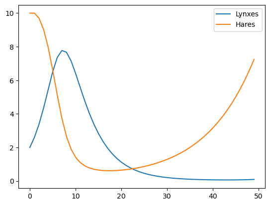

```python
dt = 0.1
c = 0.5
g_H = 1
d_L = 2

hare_pop = []
lynx_pop = []

hare_pop.append(10)
lynx_pop.append(2)

for time_step in range (1, 50):
    hare_new = hare_pop[time_step-1] + dt*(g_H*hare_pop[time_step-1] - c*lynx_pop[time_step-1]*hare_pop[time_step-1])
    lynx_new = lynx_pop[time_step-1] + dt*(c*lynx_pop[time_step-1]*hare_pop[time_step-1] - d_L*lynx_pop[time_step-1])
    hare_pop.append(hare_new)
    lynx_pop.append(lynx_new)

plt.plot(range(0,50), lynx_pop)
plt.plot(range(0,50), hare_pop)
legend_text = ["Lynxes", "Hares"]
plt.legend(legend_text)
```

Plotting the hare and lynx populations with the starting populations H(0) = 10 and L(0) = 2, we can see a generally inverse relationship between hare and lynx populations. As the lynx population grows (feeding on hares), the hare population declines, and visa versa. We see that in this model, the lynx population runs out of food and does not recover, while the hare population runs rampant with no predator.

b. Describe in words what happens if a lynx disease causes their death rate to increase 4x. Now consider what happens if, as a result of their higher death rate, lynx become 3x better at catching and eating hares. Plot each of these three scenarios over the first 10 days and carefully describe the results. Are you surprised?

If the lynx death rate, d_L, increases 4 times to 8 lynxes/time step, the lynx population would die out very quickly, likely decreasing immediately from 2 to 0. The hare population how lacks a predator and so it would grow unbounded.

Now, if lynx become 3x better at catching hares, hence increasing the capture rate, c, three-fold to 1.5 hares/time step, the lynx population will not decline so rapidly, though I would imaging it would still ultimately decline since a death rate of 8 lynxes/time step is much more extreme than a growth rate of 1.5. This would affect the hares by bounding their growth, though again, as the lynxes die out the hares will ultimately still grow unbounded.

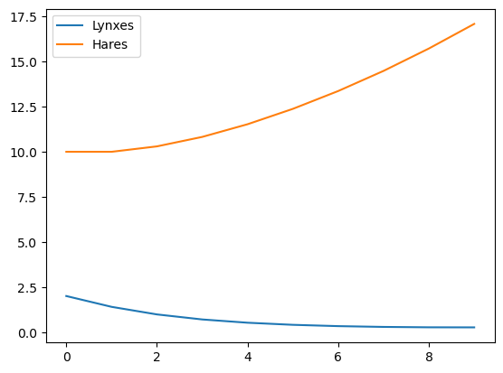

```python
dt = 0.1
c = 0.5
g_H = 1
d_L = 2*4

hare_pop = []
lynx_pop = []

hare_pop.append(10)
lynx_pop.append(2)

for time_step in range (1, 10):
    hare_new = hare_pop[time_step-1] + dt*(g_H*hare_pop[time_step-1] - c*lynx_pop[time_step-1]*hare_pop[time_step-1])
    lynx_new = lynx_pop[time_step-1] + dt*(c*lynx_pop[time_step-1]*hare_pop[time_step-1] - d_L*lynx_pop[time_step-1])
    hare_pop.append(hare_new)
    lynx_pop.append(lynx_new)

plt.plot(range(0,10), lynx_pop)
plt.plot(range(0,10), hare_pop)
legend_text = ["Lynxes", "Hares"]
plt.legend(legend_text)
```

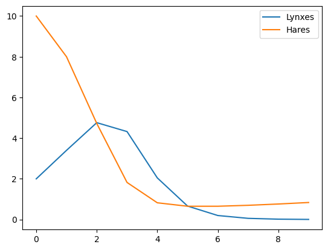

```python
dt = 0.1
c = 0.5*3
g_H = 1
d_L = 2*4

hare_pop = []
lynx_pop = []

hare_pop.append(10)
lynx_pop.append(2)

for time_step in range (1, 10):
    hare_new = hare_pop[time_step-1] + dt*(g_H*hare_pop[time_step-1] - c*lynx_pop[time_step-1]*hare_pop[time_step-1])
    lynx_new = lynx_pop[time_step-1] + dt*(c*lynx_pop[time_step-1]*hare_pop[time_step-1] - d_L*lynx_pop[time_step-1])
    hare_pop.append(hare_new)
    lynx_pop.append(lynx_new)

plt.plot(range(0,10), lynx_pop)
plt.plot(range(0,10), hare_pop)
legend_text = ["Lynxes", "Hares"]
plt.legend(legend_text)
```

The second plot (lynx death rate of 4, no change to c) is as expected: the lynx population rapidly declines while the hare population grows unbounded. The third plot is slightly surprising. I expected the lynx rate to rise at first but ultimately be overcome by the death rate term and die out, but I did not expect the affect of an increased c value to cause the hare population to decline as much as it did. However, it looks like the hare population is not 0 and the slope is moving upwards, so I would guess that the hare population does ultimately recover as I predicted.

c. Simulate the dynamics using the parameters from part (a) for 20 days. At day 20, the hares ran out of grass to eat. Change the growth rate of hares to 0.01 and simulate the model for another 20 days. Describe in words what has happened. Mathematically, what has happened?

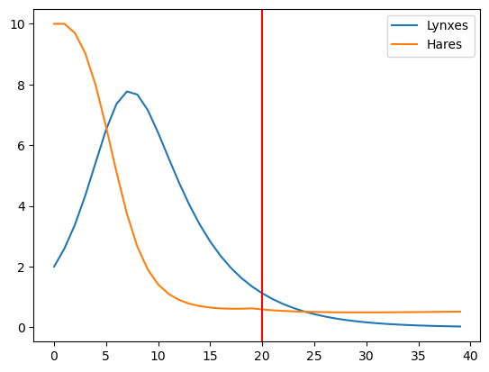

```python
dt = 0.1
c = 0.5
g_H = 1
d_L = 2

hare_pop = []
lynx_pop = []

hare_pop.append(10)
lynx_pop.append(2)

for time_step in range (1, 20):
    hare_new = hare_pop[time_step-1] + dt*(g_H*hare_pop[time_step-1] - c*lynx_pop[time_step-1]*hare_pop[time_step-1])
    lynx_new = lynx_pop[time_step-1] + dt*(c*lynx_pop[time_step-1]*hare_pop[time_step-1] - d_L*lynx_pop[time_step-1])
    hare_pop.append(hare_new)
    lynx_pop.append(lynx_new)

g_H = 0.1

for time_step in range (20, 40):
    hare_new = hare_pop[time_step-1] + dt*(g_H*hare_pop[time_step-1] - c*lynx_pop[time_step-1]*hare_pop[time_step-1])
    lynx_new = lynx_pop[time_step-1] + dt*(c*lynx_pop[time_step-1]*hare_pop[time_step-1] - d_L*lynx_pop[time_step-1])
    hare_pop.append(hare_new)
    lynx_pop.append(lynx_new)

plt.plot(range(0,40), lynx_pop)
plt.plot(range(0,40), hare_pop)
plt.axvline(x=20, color="red") # shows where the food runs out
legend_text = ["Lynxes", "Hares"]
plt.legend(legend_text)
```

The population begins as normal, with the inverse relationship between hare and lynx populations. However, at time step 20, the hare population runs out of food and is unable to recover from its low point. Rather, it decreases and plateaus. The lynx population is also affected because it too runs out of food (hares), and so it also decreases and plateaus. It is interesting that the lynx population actually ends up less than the hare population, though this could be because of the smaller starting population or the difference in growth/death rates.

Mathematically, the growth term for the hare population model is significantly decrased, leading to a derivative that is first negative and then ~0. The growth rate of the lynxes, which is dependent on the population of hares, is also significantly decreased, leading also to a negative and then ~0 derivative for the lynx population.